# Implementing Variational Inference using `pytorch`

`pytorch` is an open-source ML framework primarily used for deep learning models, developed by Meta AI, and favored for its pythonic design.

```python
import torch
import torch.nn as nn
torch.manual_seed(0)
import numpy as np
import matplotlib.pyplot as plt
```

Let's go back to our bimodal mixture of Gaussian from the last unit and set that as our target distribution $$p^*(x) \propto 0.5 \mathcal{N}(x; 1, 6) + 0.5 \mathcal{N}(x;-2, 1)$$

```python
def log_pstar(x):
    # log p^*(x)
    log_p1 = torch.distributions.Normal(1, 6).log_prob(x)
    log_p2 = torch.distributions.Normal(-2, 1).log_prob(x)

    log_mix = torch.stack([log_p1, log_p2], dim=0)
    return torch.logsumexp(log_mix, dim=0) - np.log(2.0)
```

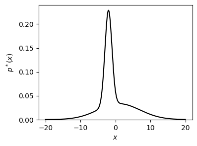

```python
_x = torch.tensor(np.linspace(-20, 20, 1000))
_logp = log_pstar(_x)

plt.figure(figsize=(4,3))
plt.plot(_x.numpy(), np.exp(_logp.numpy()), c='k')
plt.xlabel('$x$'); plt.ylabel('$p^*(x)$')
plt.ylim(0, None); plt.show()
```

Now to implement variation inference we need to

1. Pick a surrogate distribution $q_\phi(x)$
2. Optimize the Kullback-Leibler divergence $\min\limits_\phi D_{\rm KL}(q_\phi \parallel p)$

For our first example, lets keep it simple and pick a mixture of two Gaussian for $q_\phi$

```python
def log_qphi(x, mu0, log_sigma0, mu1, log_sigma1):
    sigma0 = torch.exp(log_sigma0)
    sigma1 = torch.exp(log_sigma1)

    log_p1 = torch.distributions.Normal(mu0, sigma0).log_prob(x)
    log_p2 = torch.distributions.Normal(mu1, sigma1).log_prob(x)

    log_mix = torch.stack([log_p1, log_p2], dim=0)
    return torch.logsumexp(log_mix, dim=0) - np.log(2.0)
```

In this case $\phi = [\mu_0, \log \sigma_0, \mu_1, \log \sigma_1]$

Now lets implement the KL divergence or ELBO: $$\min\limits_\phi D_{\rm KL}(q_\phi \parallel p^*) = \min\limits_\phi \int{\rm d}x~q_\phi(x)~\log \frac{q_\phi(x)}{p^*(x)}$$

Recall that we can approximate $D_{\rm KL}$ using MC integration as: $$D_{\rm KL}(q_\phi \parallel p^*) \approx \sum\limits_{x'\sim q_\phi(x)} \left[ \log q_\phi(x') - \log p^*(x)\right]$$

```python
def KL_div(mu0, log_sigma0, mu1, log_sigma1, n_samples=256):
    # Kullback-Leibler divergence
    sigma0 = torch.exp(log_sigma0)
    sigma1 = torch.exp(log_sigma1)

    # reparameterisation trick
    eps = torch.randn(n_samples)
    x = torch.concatenate([mu0+sigma0*eps[:n_samples//2],
                           mu1+sigma1*eps[n_samples//2:]])

    # Monte-Carlo estimate of KL divergence
    log_p = log_pstar(x)
    log_q = log_qphi(x, mu0, log_sigma0, mu1, log_sigma1)

    return (log_q - log_p).mean()
```

Now let's minimize the KL divergence

```python
# initialize phi
mu0        = nn.Parameter(torch.tensor([1.0]))
log_sigma0 = nn.Parameter(torch.tensor([0.0]))
mu1        = nn.Parameter(torch.tensor([-1.0]))
log_sigma1 = nn.Parameter(torch.tensor([0.0]))
```

We'll use the `Adam` optimizer (Kingma & Ba 2014), a gradient-based optimizer that uses a running average of past gradients and past squared graidents for adaptive step sizes and faster convergence.

```python
optimizer = torch.optim.Adam([mu0, log_sigma0, mu1, log_sigma1], lr=0.05)
```

```python
print(r'Epoch       mu0     sigma0    mu1      sigma1      Loss' )
for step in range(1, 501):
    optimizer.zero_grad()
    loss = KL_div(mu0, log_sigma0, mu1, log_sigma1)
    loss.backward()
    optimizer.step()

    if step % 50 == 0:
        sigma0 = torch.exp(log_sigma0).item()
        sigma1 = torch.exp(log_sigma1).item()
        print(f"{step:>6}  {mu0.item():>8.4f}  {sigma0:>8.4f} {mu1.item():>8.4f}  {sigma1:>8.4f}  {loss.item():>10.4f}")
```

```
Epoch       mu0     sigma0    mu1      sigma1      Loss
    50    1.3247    6.7719  -2.1161    1.0572      0.0098
   100    0.9674    6.0063  -2.0101    0.9975      0.0017
   150    0.9464    5.7457  -2.0306    1.0547      0.0078
   200    0.9382    6.0313  -2.0235    0.9515     -0.0003
   250    0.7257    5.8659  -2.0289    0.9926     -0.0008
   300    1.0068    5.9061  -2.0273    1.0419      0.0009
   350    1.1212    5.7768  -1.9866    0.9898     -0.0025
   400    0.9051    5.9057  -2.0252    1.0335      0.0004
   450    0.9381    6.3503  -2.0011    0.9988      0.0049
   500    1.3181    5.9872  -1.9878    0.9388      0.0021
```

Let's check our $q_\phi$ estimate

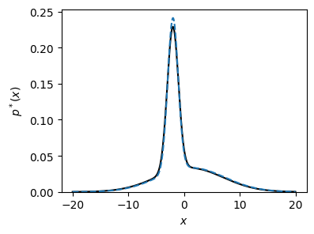

```python
_logq = log_qphi(_x, mu0, log_sigma0, mu1, log_sigma1)

plt.figure(figsize=(4,3))
plt.plot(_x.numpy(), np.exp(_logp.numpy()), c='k')
plt.plot(_x.numpy(), np.exp(_logq.detach().numpy()), ls='--')
plt.xlabel('$x$'); plt.ylabel('$p^*(x)$')
plt.ylim(0, None); plt.show()
```

Excellent agreement.

More importantly, we can now use $q_\phi$ to sample $p^*$

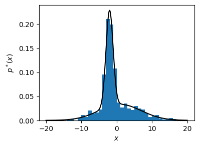

```python
# reparameterisation trick to sample q_phi
eps = torch.randn(1000)
xprime = np.concatenate([
    mu0.item()+np.exp(log_sigma0.item())*eps[:500],
    mu1.item()+np.exp(log_sigma1.item())*eps[500:]])

plt.figure(figsize=(4,3))
plt.plot(_x.numpy(), np.exp(_logp.numpy()), c='k')
plt.hist(xprime, density=True, range=(-20, 20), bins=40)
plt.xlabel('$x$'); plt.ylabel('$p^*(x)$'); plt.show()
```

# proposal distribution $q_\phi$

In the previous example, we chose correct functional form. Of course, in practice we often don't know this.

So what happens if we choose poorly?

Let's choose a functional form that we know is incorrect $$q_\phi = \mathcal{N}(x; \mu, \sigma)$$

```python
def log_qphi(x, mu, log_sigma):
    sigma = torch.exp(log_sigma)
    return torch.distributions.Normal(mu, sigma).log_prob(x)
```

We can reimplement the KL divergence

```python
def KL_div(mu, log_sigma, n_samples=256):
    # Kullback-Leibler divergence
    sigma = torch.exp(log_sigma)

    # reparameterisation trick
    eps = torch.randn(n_samples)
    x = mu + sigma * eps

    # Monte-Carlo estimate of KL divergence
    log_p = log_pstar(x)
    log_q = log_qphi(x, mu, log_sigma)

    return (log_q - log_p).mean()
```

Reinitialize $\phi$ and the Adam optimizer

```python
mu        = nn.Parameter(torch.tensor([.0]))
log_sigma = nn.Parameter(torch.tensor([0.0]))
optimizer = torch.optim.Adam([mu, log_sigma], lr=0.05)
```

And rerun the optimization for 500 epochs

```python
print(r'Epoch       mu     sigma      Loss' )
for step in range(1, 501):
    optimizer.zero_grad()
    loss = KL_div(mu, log_sigma)
    loss.backward()
    optimizer.step()

    if step % 50 == 0:
        sigma = torch.exp(log_sigma).item()
        print(f"{step:>6}  {mu.item():>8.4f}  {sigma:>8.4f}  {loss.item():>10.4f}")
```

```
Epoch       mu     sigma      Loss
    50   -1.2842    4.0977      0.3487
   100   -0.9918    4.0852      0.2097
   150   -0.7965    4.0980      0.3304
   200   -0.6035    4.1330      0.2417
   250   -0.5046    4.2019      0.2141
   300   -0.5088    4.3323      0.2115
   350   -0.5111    4.3813      0.1967
   400   -0.6415    4.3239      0.2992
   450   -0.6616    4.3571      0.2365
   500   -0.7325    4.0209      0.1978
```

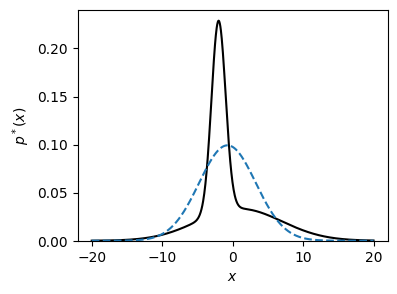

```python
_logq = log_qphi(_x, mu, log_sigma)

plt.figure(figsize=(4,3))
plt.plot(_x.numpy(), np.exp(_logp.numpy()), c='k')
plt.plot(_x.numpy(), np.exp(_logq.detach().numpy()), ls='--')
plt.xlabel('$x$'); plt.ylabel('$p^*(x)$')
plt.ylim(0, None); plt.show()
```

$q_\phi$ does not accurately estimate our target distribution $p^*(x)$

### variation inference is sensitive to choice of $q_\phi$

# variational inference for Bayesian inference

Now let's try using VI for our favorite Bayesian inference problem of fitting a line to data

```python
import corner
```

```python
a_true, b_true = 0, 1.75
x = torch.tensor([1,1.5,2,2.5])
y = torch.tensor([1.87640523, 2.59001572, 3.4978738 , 4.47408932])
yerr = 0.1
```

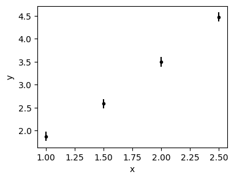

```python
plt.figure(figsize=(4,3))
plt.errorbar(x, y, yerr=yerr, fmt='.k')
plt.xlabel('x'); plt.ylabel('y')
```

Let's set up our model, likelihood, prior, and posterior as before

```python
def model(theta, x):
    a, b = theta.T
    return (a + b * x[:,None]).T
```

```python
def log_likelihood(theta, x, y, yerr):
    m = model(theta, x)
    return -0.5 * torch.sum((y - m) ** 2 / yerr**2, dim=1)

def log_prior(theta):
    a, b = theta[:, 0], theta[:, 1]

    in_bounds = ((a >= -10) & (a <= 10) & (b >= -10) & (b <= 10))

    logp = torch.zeros(theta.shape[0])
    logp[~in_bounds] = -torch.inf
    return logp

def log_posterior(theta, x, y, yerr):
    lp = log_prior(theta)
    return lp + log_likelihood(theta, x, y, yerr)
```

Now let's pick our proposal distribution --- a 2D multivariate Gaussian.

quick note: rather than the covariance matrix we're going to provide a lower-triangular Cholesky factor (lower triangular matrix with positive diagonal entries) to ensure that the covariance matrix is postive definite

```python
def log_qphi(x, mu, log_diag, offdiag):
    diag = torch.exp(log_diag)
    L = torch.zeros((2,2))
    L[0,0] = diag[0]
    L[1,1] = diag[1]
    L[1,0] = offdiag
    return torch.distributions.MultivariateNormal(mu, scale_tril=L).log_prob(x)
```

Next, we can set up the KL divergence similar as before but with the posterior $p(\theta\,|\,X)$ as the target distribution

```python
def KL_div(mu, log_diag, offdiag, _x, _y, _yerr, n_samples=256):
    diag = torch.exp(log_diag)
    L = torch.zeros((2,2))
    L[0,0] = diag[0]
    L[1,1] = diag[1]
    L[1,0] = offdiag

    # sample q_phi
    _dist = torch.distributions.MultivariateNormal(mu, scale_tril=L)
    thetap = _dist.rsample((n_samples,))

    # Monte-Carlo estimate of KL divergence
    log_p = log_posterior(thetap, _x, _y, _yerr)
    log_q = log_qphi(thetap, mu, log_diag, offdiag)

    return (log_q - log_p).mean()
```

Initialize $\phi$ and the optimizer

```python
mu        = nn.Parameter(torch.tensor([0., .0]))
log_diag  = nn.Parameter(torch.tensor([0., 0.]))
offdiag   = nn.Parameter(torch.tensor(0.))
optimizer = torch.optim.Adam([mu, log_diag, offdiag], lr=0.05)
```

And optimize!

```python
for step in range(1, 1001):
    optimizer.zero_grad()
    loss = KL_div(mu, log_diag, offdiag, x, y, yerr)
    loss.backward()
    optimizer.step()

    if step % 200 == 0:
        print(f"{step:>6}  {loss.item():>10.4f}")
```

```
   200     16.9050
   400      6.6993
   600      5.0689
   800      4.7341
  1000      4.5904
```

Let's check the estimated posterior samples from variational inference

```python
diag = torch.exp(log_diag)
L = torch.tensor([[diag[0], 0.], [offdiag, diag[1]]])
_dist = torch.distributions.MultivariateNormal(mu, scale_tril=L)
samples = _dist.sample((10000,))
```

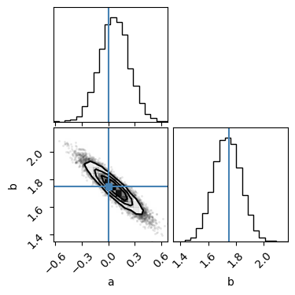

```python
fig = plt.figure(figsize=(4,4))
fig = corner.corner(samples.detach().numpy(), labels=["a", "b"],
                    truths=[a_true, b_true], fig=fig)
```

# unit summary

- Variational inference reformulates probability distribution estimation into an **optimization** problem --- speed benefits of optimization + statistical benefits of having the full distribution
- Kullback-Leibler (KL) divergence from information theory is an effective metric to discriminate between $q_\phi$ and $p^*$.
- implementation of variational inference using `pytorch`
- variational inference is sensitive to choice of proposal distribution $q_\phi$